# Credit Card Fraud Detection Example

# 1 Introduction

Source: https://www.kaggle.com/mlg-ulb/creditcardfraud

The datasets contains transactions made by credit cards in September 2013 by european cardholders. This dataset presents transactions that occurred in two days, where we have 492 frauds out of 284,807 transactions. The dataset is highly unbalanced, the positive class (frauds) account for 0.172% of all transactions.

It contains only numerical input variables which are the result of a PCA transformation. Unfortunately, due to confidentiality issues, we cannot provide the original features and more background information about the data. Features V1, V2, … V28 are the principal components obtained with PCA, the only features which have not been transformed with PCA are ‘Time’ and ‘Amount’. Feature ‘Time’ contains the seconds elapsed between each transaction and the first transaction in the dataset. The feature ‘Amount’ is the transaction Amount, this feature can be used for example-dependant cost-senstive learning. Feature ‘Class’ is the response variable and it takes value 1 in case of fraud and 0 otherwise.

# 2 H2O in R

```r
# Start H2O Local Cluster
library(h2o)
h2o.init(nthreads = -1, max_mem_size = "8g")
```

```
##  Connection successful!
##
## R is connected to the H2O cluster:
##     H2O cluster uptime:         19 hours 15 minutes
##     H2O cluster timezone:       Europe/Amsterdam
##     H2O data parsing timezone:  UTC
##     H2O cluster version:        3.18.0.1
##     H2O cluster version age:    9 days
##     H2O cluster name:           H2O_from_python_jofaichow_rd3hff
##     H2O cluster total nodes:    1
##     H2O cluster total memory:   2.88 GB
##     H2O cluster total cores:    8
##     H2O cluster allowed cores:  8
##     H2O cluster healthy:        TRUE
##     H2O Connection ip:          localhost
##     H2O Connection port:        54321
##     H2O Connection proxy:       NA
##     H2O Internal Security:      FALSE
##     H2O API Extensions:         XGBoost, Algos, AutoML, Core V3, Core V4
##     R Version:                  R version 3.4.3 (2017-11-30)
```

```r
h2o.no_progress() # disable the progress bar in HTML output
```

# 3 Data

```r
# import credit card data
h_creditcard = h2o.importFile("/Users/jofaichow/Documents/repo_h2o/h2o_training_2018_02/examples/credit_card_fraud/creditcard.csv")
```

```r
# Convert "Class" into factor
h_creditcard$Class = as.factor(h_creditcard$Class)
h2o.table(h_creditcard$Class)
```

```
##   Class  Count
## 1     0 284315
## 2     1    492
##
## [2 rows x 2 columns]
```

```r
# Quick look
head(h_creditcard)
```

```
##   Time         V1          V2        V3         V4          V5          V6
## 1    0 -1.3598071 -0.07278117 2.5363467  1.3781552 -0.33832077  0.46238778
## 2    0  1.1918571  0.26615071 0.1664801  0.4481541  0.06001765 -0.08236081
## 3    1 -1.3583541 -1.34016307 1.7732093  0.3797796 -0.50319813  1.80049938
## 4    1 -0.9662717 -0.18522601 1.7929933 -0.8632913 -0.01030888  1.24720317
## 5    2 -1.1582331  0.87773675 1.5487178  0.4030339 -0.40719338  0.09592146
## 6    2 -0.4259659  0.96052304 1.1411093 -0.1682521  0.42098688 -0.02972755
##            V7          V8         V9         V10        V11         V12
## 1  0.23959855  0.09869790  0.3637870  0.09079417 -0.5515995 -0.61780086
## 2 -0.07880298  0.08510165 -0.2554251 -0.16697441  1.6127267  1.06523531
## 3  0.79146096  0.24767579 -1.5146543  0.20764287  0.6245015  0.06608369
## 4  0.23760894  0.37743587 -1.3870241 -0.05495192 -0.2264873  0.17822823
## 5  0.59294075 -0.27053268  0.8177393  0.75307443 -0.8228429  0.53819555
## 6  0.47620095  0.26031433 -0.5686714 -0.37140720  1.3412620  0.35989384
##          V13        V14        V15        V16         V17         V18
```

[output cut: 20 more lines]

```r
summary(h_creditcard)
```

```
##  Time             V1                   V2
##  Min.   :     0   Min.   :-5.641e+01   Min.   :-7.272e+01
##  1st Qu.: 54084   1st Qu.:-9.591e-01   1st Qu.:-6.879e-01
##  Median : 84669   Median :-1.729e-02   Median :-2.449e-02
##  Mean   : 94814   Mean   : 1.073e-15   Mean   : 4.151e-16
##  3rd Qu.:139271   3rd Qu.: 1.278e+00   3rd Qu.: 7.337e-01
##  Max.   :172792   Max.   : 2.455e+00   Max.   : 2.206e+01
##  V3                   V4                   V5
##  Min.   :-4.833e+01   Min.   :-5.683e+00   Min.   :-1.137e+02
##  1st Qu.:-9.472e-01   1st Qu.:-8.556e-01   1st Qu.:-7.006e-01
##  Median : 1.493e-01   Median :-2.098e-02   Median :-1.064e-01
##  Mean   :-1.022e-15   Mean   : 2.031e-15   Mean   : 1.022e-15
##  3rd Qu.: 1.015e+00   3rd Qu.: 7.234e-01   3rd Qu.: 4.878e-01
##  Max.   : 9.383e+00   Max.   : 1.688e+01   Max.   : 3.480e+01
##  V6                   V7                   V8
##  Min.   :-2.616e+01   Min.   :-4.356e+01   Min.   :-7.322e+01
##  1st Qu.:-7.977e-01   1st Qu.:-7.149e-01   1st Qu.:-2.224e-01
##  Median :-3.004e-01   Median :-5.836e-02   Median :-3.594e-02
##  Mean   : 1.418e-15   Mean   :-6.004e-16   Mean   : 1.405e-16
##  3rd Qu.: 3.959e-01   3rd Qu.: 4.341e-01   3rd Qu.: 2.437e-01
##  Max.   : 7.330e+01   Max.   : 1.206e+02   Max.   : 2.001e+01
##  V9                   V10                  V11
##  Min.   :-1.343e+01   Min.   :-2.459e+01   Min.   :-4.797e+00
##  1st Qu.:-6.613e-01   1st Qu.:-5.666e-01   1st Qu.:-7.784e-01
##  Median :-5.167e-02   Median :-1.316e-01   Median :-3.844e-02
##  Mean   :-2.516e-15   Mean   : 2.208e-15   Mean   : 1.788e-15
##  3rd Qu.: 5.870e-01   3rd Qu.: 4.484e-01   3rd Qu.: 7.351e-01
##  Max.   : 1.559e+01   Max.   : 2.375e+01   Max.   : 1.202e+01
##  V12                  V13                  V14
##  Min.   :-1.868e+01   Min.   :-5.792e+00   Min.   :-1.921e+01
##  1st Qu.:-4.296e-01   1st Qu.:-6.502e-01   1st Qu.:-4.477e-01
##  Median : 1.275e-01   Median :-1.719e-02   Median : 2.816e-02
##  Mean   :-1.169e-15   Mean   : 7.983e-16   Mean   : 1.099e-15
##  3rd Qu.: 6.051e-01   3rd Qu.: 6.546e-01   3rd Qu.: 4.743e-01
##  Max.   : 7.848e+00   Max.   : 7.127e+00   Max.   : 1.053e+01
##  V15                  V16                  V17
##  Min.   :-4.499e+00   Min.   :-1.413e+01   Min.   :-2.516e+01
##  1st Qu.:-5.930e-01   1st Qu.:-4.827e-01   1st Qu.:-4.863e-01
##  Median : 3.575e-02   Median : 5.183e-02   Median :-7.330e-02
##  Mean   : 4.982e-15   Mean   : 1.421e-15   Mean   :-3.513e-16
```

[output cut: 15 more lines]

```
##  Max.   : 2.720e+01   Max.   : 1.050e+01   Max.   : 2.253e+01
##  V24                  V25                  V26
##  Min.   :-2.837e+00   Min.   :-1.030e+01   Min.   :-2.605e+00
##  1st Qu.:-3.580e-01   1st Qu.:-3.190e-01   1st Qu.:-3.272e-01
##  Median : 3.537e-02   Median : 1.665e-03   Median :-5.784e-02
##  Mean   : 4.472e-15   Mean   : 4.982e-16   Mean   : 1.700e-15
##  3rd Qu.: 4.361e-01   3rd Qu.: 3.401e-01   3rd Qu.: 2.360e-01
##  Max.   : 4.585e+00   Max.   : 7.520e+00   Max.   : 3.517e+00
##  V27                  V28                  Amount             Class
##  Min.   :-2.257e+01   Min.   :-1.543e+01   Min.   :    0.00   0:284315
##  1st Qu.:-8.186e-02   1st Qu.:-5.538e-02   1st Qu.:    0.00   1:   492
##  Median :-2.768e-02   Median :-6.104e-03   Median :    0.00
##  Mean   :-3.688e-16   Mean   :-1.211e-16   Mean   :   88.35
##  3rd Qu.: 8.067e-02   3rd Qu.: 4.317e-02   3rd Qu.:   77.07
##  Max.   : 3.161e+01   Max.   : 3.385e+01   Max.   :25691.16
```

```r
# Split data into training / validation / holdout
h_split = h2o.splitFrame(h_creditcard, ratios = c(0.8, 0.1), seed = 1234)
h_train = h_split[[1]]
h_valid = h_split[[2]]
h_holdout = h_split[[3]]
```

```r
# Quick look
h2o.table(h_train$Class)
```

```
##   Class  Count
## 1     0 227696
## 2     1    389
##
## [2 rows x 2 columns]
```

```r
h2o.table(h_valid$Class)
```

```
##   Class Count
## 1     0 28034
## 2     1    51
##
## [2 rows x 2 columns]
```

```r
h2o.table(h_holdout$Class)
```

```
##   Class Count
## 1     0 28585
## 2     1    52
##
## [2 rows x 2 columns]
```

# 4 Supervised Learning: Build a Baseline (Random Forest) Model

```r
# Define features
features = setdiff(colnames(h_creditcard), "Class")
print(features)
```

```
##  [1] "Time"   "V1"     "V2"     "V3"     "V4"     "V5"     "V6"
##  [8] "V7"     "V8"     "V9"     "V10"    "V11"    "V12"    "V13"
## [15] "V14"    "V15"    "V16"    "V17"    "V18"    "V19"    "V20"
## [22] "V21"    "V22"    "V23"    "V24"    "V25"    "V26"    "V27"
## [29] "V28"    "Amount"
```

```r
# Baseline Random Forest model
model_baseline = h2o.randomForest(x = features,
                                     y = "Class",
                                     training_frame = h_train,
                                     validation_frame = h_valid,
                                     model_id = "baseline",
                                     seed = 1234)
print(model_baseline)
```

```
## Model Details:
## ==============
##
## H2OBinomialModel: drf
## Model ID:  baseline
## Model Summary:
##   number_of_trees number_of_internal_trees model_size_in_bytes min_depth
## 1              50                       50              122777        18
##   max_depth mean_depth min_leaves max_leaves mean_leaves
## 1        20   19.96000        139        252   190.68000
##
##
## H2OBinomialMetrics: drf
## ** Reported on training data. **
## ** Metrics reported on Out-Of-Bag training samples **
##
## MSE:  0.0004208072
## RMSE:  0.02051359
## LogLoss:  0.005170564
## Mean Per-Class Error:  0.100301
## AUC:  0.9363443
## Gini:  0.8726887
##
## Confusion Matrix (vertical: actual; across: predicted) for F1-optimal threshold:
##             0   1    Error        Rate
## 0      227676  20 0.000088  =20/227696
## 1          78 311 0.200514     =78/389
## Totals 227754 331 0.000430  =98/228085
##
## Maximum Metrics: Maximum metrics at their respective thresholds
##                         metric threshold    value idx
## 1                       max f1  0.428571 0.863889  78
## 2                       max f2  0.200000 0.838909 103
## 3                 max f0point5  0.590909 0.914445  62
## 4                 max accuracy  0.428571 0.999570  78
## 5                max precision  1.000000 1.000000   0
## 6                   max recall  0.000000 1.000000 399
## 7              max specificity  1.000000 1.000000   0
## 8             max absolute_mcc  0.428571 0.866500  78
## 9   max min_per_class_accuracy  0.000067 0.897172 386
```

[output cut: 18 more lines]

```
##
## Maximum Metrics: Maximum metrics at their respective thresholds
##                         metric threshold    value idx
## 1                       max f1  0.320000 0.868687  16
## 2                       max f2  0.320000 0.853175  16
## 3                 max f0point5  0.460000 0.890411  11
## 4                 max accuracy  0.320000 0.999537  16
## 5                max precision  0.960000 0.952381   2
## 6                   max recall  0.000003 1.000000 393
## 7              max specificity  1.000000 0.999964   0
## 8             max absolute_mcc  0.320000 0.868856  16
## 9   max min_per_class_accuracy  0.000248 0.921569 295
## 10 max mean_per_class_accuracy  0.000248 0.940969 295
##
## Gains/Lift Table: Extract with `h2o.gainsLift(<model>, <data>)` or `h2o.gainsLift(<model>, valid=<T/F>, xval=<T/F>)`
```

```r
# Check performance on holdout
h2o.performance(model_baseline, newdata = h_holdout)
```

```
## H2OBinomialMetrics: drf
##
## MSE:  0.0003861288
## RMSE:  0.01965016
## LogLoss:  0.004139588
## Mean Per-Class Error:  0.08655595
## AUC:  0.9470648
## Gini:  0.8941295
##
## Confusion Matrix (vertical: actual; across: predicted) for F1-optimal threshold:
##            0  1    Error       Rate
## 0      28584  1 0.000035   =1/28585
## 1          9 43 0.173077      =9/52
## Totals 28593 44 0.000349  =10/28637
##
## Maximum Metrics: Maximum metrics at their respective thresholds
##                         metric threshold    value idx
## 1                       max f1  0.450000 0.895833  18
## 2                       max f2  0.380000 0.862745  21
## 3                 max f0point5  0.500000 0.954545  16
## 4                 max accuracy  0.500000 0.999651  16
## 5                max precision  1.000000 1.000000   0
## 6                   max recall  0.000000 1.000000 399
## 7              max specificity  1.000000 1.000000   0
## 8             max absolute_mcc  0.450000 0.898796  18
## 9   max min_per_class_accuracy  0.000091 0.920483 336
## 10 max mean_per_class_accuracy  0.002192 0.935294 180
##
## Gains/Lift Table: Extract with `h2o.gainsLift(<model>, <data>)` or `h2o.gainsLift(<model>, valid=<T/F>, xval=<T/F>)`
```

```r
# Variable Importance
h2o.varimp(model_baseline)
```

```
## Variable Importances:
##   variable relative_importance scaled_importance percentage
## 1      V12         3182.280029          1.000000   0.221015
## 2      V17         2949.157471          0.926744   0.204824
## 3      V14         1399.605103          0.439812   0.097205
## 4      V16         1003.682739          0.315397   0.069707
## 5      V10          844.371826          0.265335   0.058643
##
## ---
##    variable relative_importance scaled_importance percentage
## 25       V8           92.360832          0.029023   0.006415
## 26      V21           80.730957          0.025369   0.005607
## 27      V27           78.615547          0.024704   0.005460
## 28   Amount           55.440380          0.017422   0.003850
## 29      V28           53.872265          0.016929   0.003742
## 30      V23           49.338184          0.015504   0.003427
```

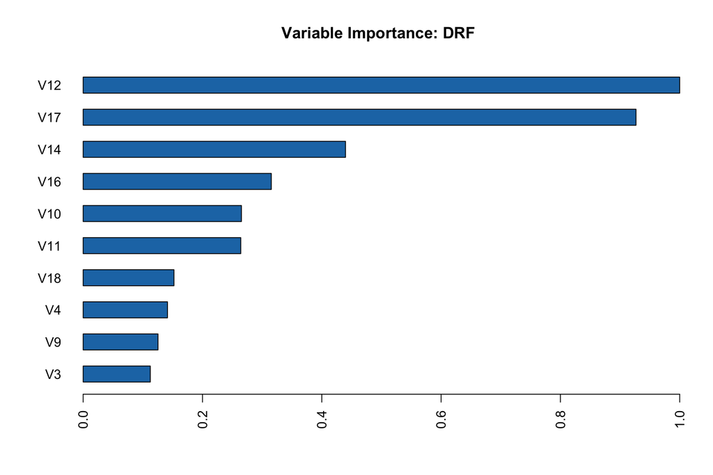

```r
# Variable Importance Plot
h2o.varimp_plot(model_baseline)
```

# 5 Unsupervised Learning: Reconstruction with Autoencoder

```r
model_autoenc = h2o.deeplearning(x = features,
                                 training_frame = h_train,
                                 validation_frame = h_valid,
                                 model_id = "autoencoder",
                                 autoencoder = TRUE,
                                 hidden = c(15),
                                 epochs = 10,
                                 activation = "Tanh",
                                 reproducible = TRUE,
                                 seed = 1234)
print(model_autoenc)
```

```
## Model Details:
## ==============
##
## H2OAutoEncoderModel: deeplearning
## Model ID:  autoencoder
## Status of Neuron Layers: auto-encoder, gaussian distribution, Quadratic loss, 945 weights/biases, 20.3 KB, 2,280,850 training samples, mini-batch size 1
##   layer units  type dropout       l1       l2 mean_rate rate_rms momentum
## 1     1    30 Input  0.00 %
## 2     2    15  Tanh  0.00 % 0.000000 0.000000  0.816484 0.196782 0.000000
## 3     3    30  Tanh         0.000000 0.000000  0.226619 0.149467 0.000000
##   mean_weight weight_rms mean_bias bias_rms
## 1
## 2   -0.012039   0.263793  0.000441 0.038379
## 3   -0.008319   0.131412 -0.002167 0.020905
##
##
## H2OAutoEncoderMetrics: deeplearning
## ** Reported on training data. **
##
## Training Set Metrics:
## =====================
##
## MSE: (Extract with `h2o.mse`) 0.000153217
## RMSE: (Extract with `h2o.rmse`) 0.01237809
##
## H2OAutoEncoderMetrics: deeplearning
## ** Reported on validation data. **
##
## Validation Set Metrics:
## =====================
##
## MSE: (Extract with `h2o.mse`) 0.0001476411
## RMSE: (Extract with `h2o.rmse`) 0.01215077
```

```r
# Calculate reconstruction errors (MSE) on training dataset
recon_err_train = h2o.anomaly(model_autoenc, h_train, per_feature = FALSE)
head(recon_err_train)
```

```
##   Reconstruction.MSE
## 1       5.898716e-05
## 2       8.861922e-05
## 3       3.414409e-04
## 4       9.270271e-05
## 5       7.651719e-05
## 6       8.766713e-05
```

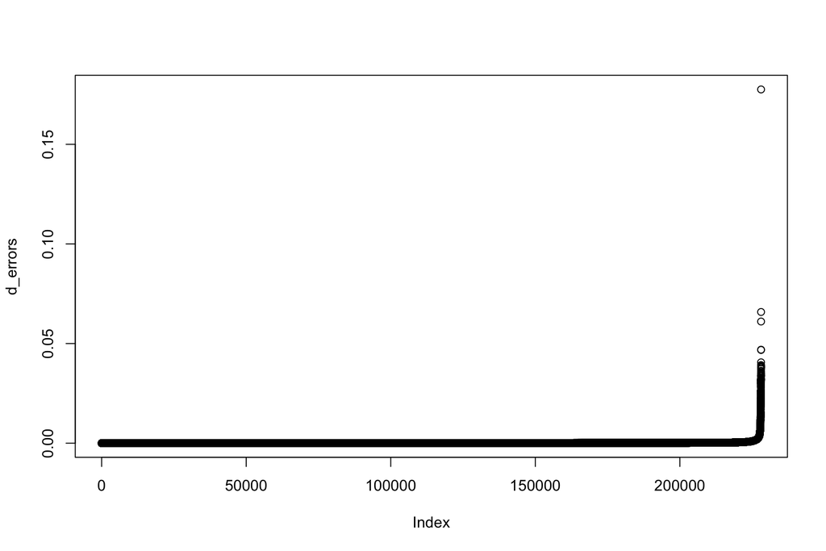

```r
# Visualise reconstruction errors
d_errors = as.data.frame(recon_err_train)
d_errors = d_errors[order(d_errors),]
plot(d_errors)
```

```r
d_recon_error_train = data.frame(Class = as.data.frame(h_train$Class),
                                 as.data.frame(recon_err_train))
head(d_recon_error_train)
```

```
##   Class Reconstruction.MSE
## 1     0       5.898716e-05
## 2     0       8.861922e-05
## 3     0       3.414409e-04
## 4     0       9.270271e-05
## 5     0       7.651719e-05
## 6     0       8.766713e-05
```

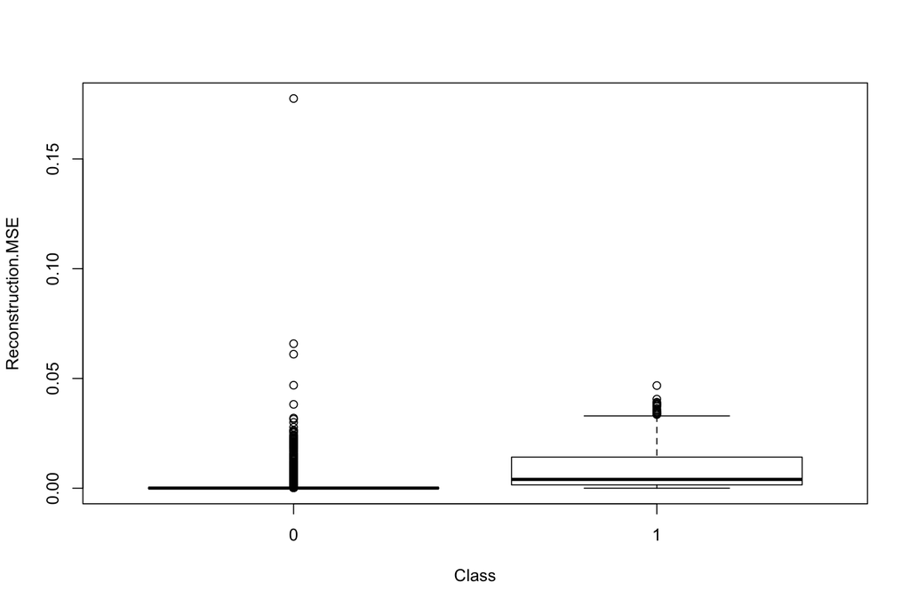

```r
plot(d_recon_error_train)
```

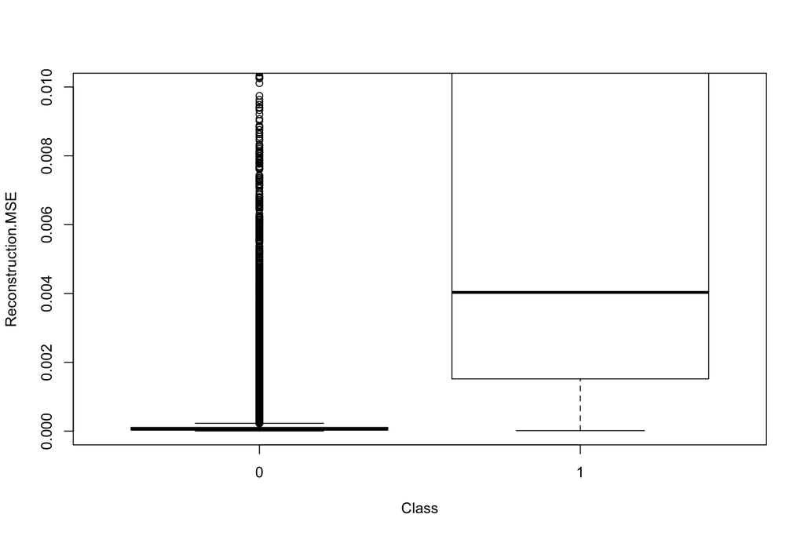

```r
plot(d_recon_error_train, ylim = c(0, 0.01))
```

# 6 5: Use a For loop to determine best threshold value

```r
# Simple For loop to try different threshold

# min
a = quantile(d_recon_error_train[d_recon_error_train$Class == 0,]$Reconstruction.MSE,
             probs = 0.75)
# max
b = quantile(d_recon_error_train[d_recon_error_train$Class == 1,]$Reconstruction.MSE,
             probs = 0.25)

# define prob
for (n_prob in c(0, 0.25, 0.5, 0.75, 1)) {

  # define threshold
  threshold = ((b - a) * n_prob) + a
  cat("\n\nProbs cutoff:", n_prob, "... Threshold:", threshold, "\n")

  # Split data
  row_train_exp = which(d_recon_error_train$Reconstruction.MSE < threshold)
  row_train_ano = which(d_recon_error_train$Reconstruction.MSE >= threshold)

  # Split training data
  h_train_exp = h_train[row_train_exp,]
  h_train_ano = h_train[row_train_ano,]

  # Train same baseline random forest model with group "Expected"
  model_exp = h2o.randomForest(x = features,
                               y = "Class",
                               training_frame = h_train_exp,
                               validation_frame = h_valid,
                               model_id = "expected",
                               seed = 1234)

  # Train same baseline random forest model with group "Anomalies"
  model_ano = h2o.randomForest(x = features,
                               y = "Class",
                               training_frame = h_train_ano,
                               validation_frame = h_valid,
                               model_id = "anomalies",
                               seed = 1234)

  # Bag the two models for holdout
  yhat_holdout_exp = h2o.predict(model_exp, h_holdout)
  yhat_holdout_ano = h2o.predict(model_ano, h_holdout)
  yhat_holdout_bag = data.frame(exp = as.data.frame(yhat_holdout_exp$p1),
                                ano = as.data.frame(yhat_holdout_ano$p1))
  yhat_holdout_bag$avg = rowMeans(yhat_holdout_bag)

  # Evaluate performance
  library(Metrics)
  d_eval_holdout = data.frame(as.data.frame(h_holdout$Class),
                              predicted = yhat_holdout_bag$avg)
  auc_holdout = Metrics::auc(d_eval_holdout$Class, d_eval_holdout$predicted)

  cat("AUC Holdout (Baseline):", h2o.auc(h2o.performance(model_baseline, h_holdout)), "\n")
  cat("AUC Holdout (Bagging):", auc_holdout, "\n")

  cat("Simple Bagging:\n")
  colnames(yhat_holdout_bag) = c("RF_expected", "RF_anomalies", "Simple_Bag")
  print(head(yhat_holdout_bag, 5))


}
```

```
##
##
## Probs cutoff: 0 ... Threshold: 0.0001086894
## AUC Holdout (Baseline): 0.9470648
## AUC Holdout (Bagging): 0.9657392
## Simple Bagging:
##   RF_expected RF_anomalies Simple_Bag
## 1           0            0          0
## 2           0            0          0
## 3           0            0          0
## 4           0            0          0
## 5           0            0          0
##
##
## Probs cutoff: 0.25 ... Threshold: 0.0004610508
## AUC Holdout (Baseline): 0.9470648
## AUC Holdout (Bagging): 0.958649
## Simple Bagging:
##    RF_expected RF_anomalies Simple_Bag
## 1 0.0000000000         0.00 0.00000000
## 2 0.0000000000         0.00 0.00000000
## 3 0.0000000000         0.00 0.00000000
## 4 0.0000000000         0.00 0.00000000
## 5 0.0001290321         0.02 0.01006452
##
##
## Probs cutoff: 0.5 ... Threshold: 0.0008134122
## AUC Holdout (Baseline): 0.9470648
## AUC Holdout (Bagging): 0.916426
## Simple Bagging:
##    RF_expected RF_anomalies Simple_Bag
## 1 0.0000000000         0.00   0.000000
## 2 0.0000000000         0.00   0.000000
## 3 0.0000000000         0.00   0.000000
## 4 0.0000000000         0.12   0.060000
## 5 0.0002499998         0.12   0.060125
##
##
## Probs cutoff: 0.75 ... Threshold: 0.001165774
## AUC Holdout (Baseline): 0.9470648
## AUC Holdout (Bagging): 0.9191255
## Simple Bagging:
##    RF_expected RF_anomalies Simple_Bag
## 1 1.163483e-06         0.02 0.01000058
## 2 3.676414e-06         0.04 0.02000184
## 3 2.000000e-02         0.00 0.01000000
## 4 0.000000e+00         0.08 0.04000000
## 5 1.163483e-06         0.06 0.03000058
##
##
## Probs cutoff: 1 ... Threshold: 0.001518135
## AUC Holdout (Baseline): 0.9470648
## AUC Holdout (Bagging): 0.9309788
## Simple Bagging:
##    RF_expected RF_anomalies Simple_Bag
## 1 5.638599e-07         0.06 0.03000028
## 2 1.008749e-05         0.06 0.03000504
## 3 0.000000e+00         0.00 0.00000000
## 4 1.358986e-06         0.06 0.03000068
## 5 8.253336e-05         0.04 0.02004127
```